# Local Adaptation and Environmental Associations

Population Genomics · PB 495/595 Plant Evolutionary Biology

George P. Tiley

10 September 2026

## Continuing from selection

- Selection leaves **local** marks on diversity against a genome-wide background.
- Selection acts on phenotypes, and sometimes, advantageous phenotypes are dependent on the environmental context. The same allele is good in one place, bad in another.
- We want to combine information about selection with environmental associations to understand local adaptation.

## Learning objectives

By the end you should be able to:

- Define **local adaptation**.
- Understand how **$F_{ST}$ outliers** and **GEA** detect adaptive loci, and their pitfalls.
- Explain **RDA** as constrained ordination — regression then PCA of the fitted values — and how **partial RDA** corrects for population structure.
- Explain why controlling for structure is critical in GEA, and how to validate candidates experimentally.

# Selection and local adaptation

## Local adaptation

**Local adaptation** occurs when a population evolves to be more **fit** in its native environment than other populations. It is the result of **spatially heterogeneous selection**.

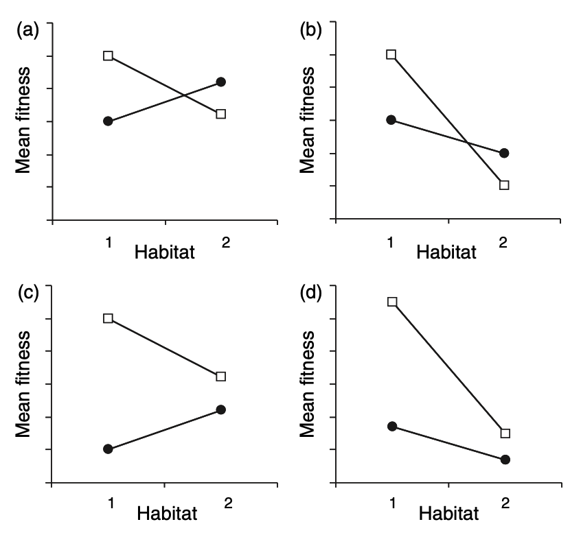

## Clines and a plant example

A **cline** is a gradient of allele frequency across an environmental transition

Adaptation to heavy metal contamination in soils is a classic example, where populations near mine boundaries evolve **metal tolerance** over very short spatial scales.

Zinc tolerance in the grass *Anthoxanthum odoratum* (Poaceae) flips over a few meters across a mine edge, despite pollen and seed flow — selection is that strong (Antonovics, Bradshaw, and Turner 1971).

## Clines and a plant example

*Silene uniflora* (Caryophyllaceae) similarly shows local adaptation to heavy metal contamination in soils. Perennial with a storage root that is subject to high exposure in contaminated environments.

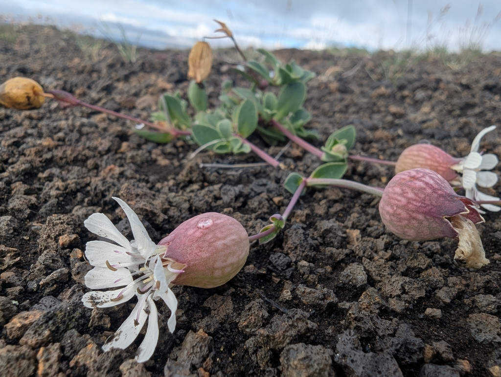

*Silene uniflora*. Photo Credit: Christopher Carlin.

## Clines and a plant example

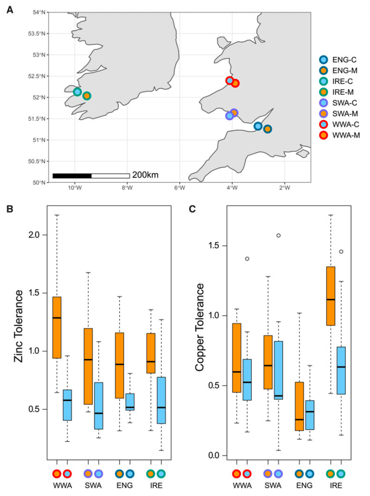

Zinc and copper tolerenace from *Silene* in Papadopulos et al. (2021)

## More cases of local adaptation in plants

Flowering time can be very important if you need to reproduce before it gets dry. Different flowering times between populations can also create **prezygotic reproductive isolation**. A well-known case of this is a **chromosomal inversion** in *Mimulus guttatus* that causes early-flowering annuals versus late-flowering perennials (Lowry and Willis 2010).

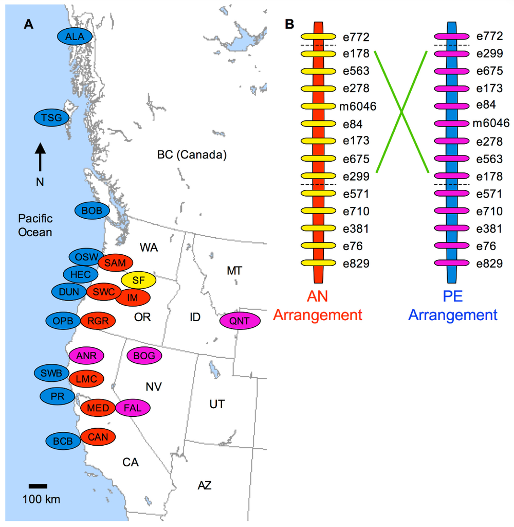

Distribution of inversion types Lowry and Willis (2010)

## More cases of local adaptation in plants

Flowering time can be very important if you need to reproduce before it gets dry. Different flowering times between populations can also create **prezygotic reproductive isolation**. A well-known case of this is a **chromosomal inversion** in *Mimulus guttatus* that causes early-flowering annuals versus late-flowering perennials (Lowry and Willis 2010).

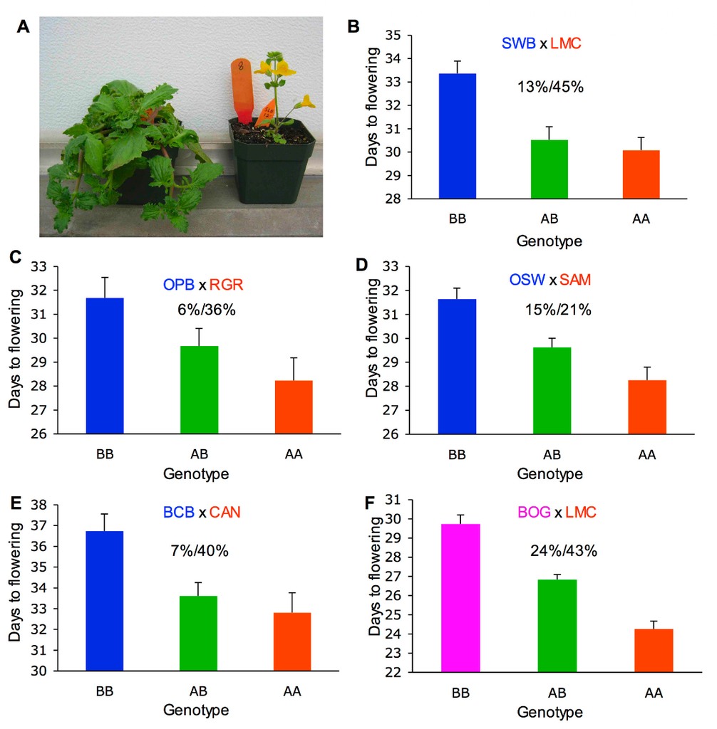

Visible phenotypic effect of inversion

## More cases of local adaptation in plants

Flowering time can be very important if you need to reproduce before it gets dry. Different flowering times between populations can also create **prezygotic reproductive isolation**. A well-known case of this is a **chromosomal inversion** in *Mimulus guttatus* that causes early-flowering annuals versus late-flowering perennials (Lowry and Willis 2010).

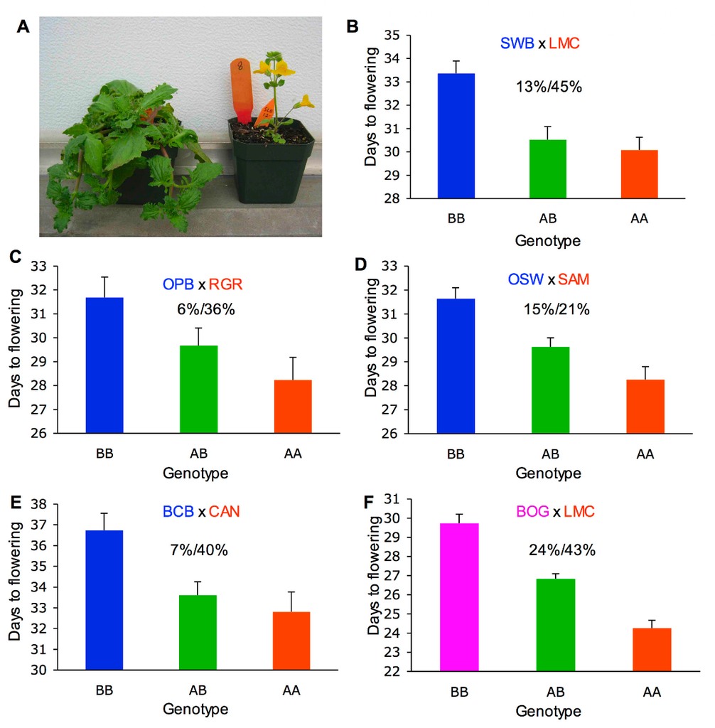

Visible phenotypic effect of inversion

## Local adaptation can be driven be a few loci

Flowering time can be very important if you need to reproduce before it gets dry. Different flowering times between populations can also create **prezygotic reproductive isolation**. A well-known case of this is a **chromosomal inversion** in *Mimulus guttatus* that causes early-flowering annuals versus late-flowering perennials (Lowry and Willis 2010).

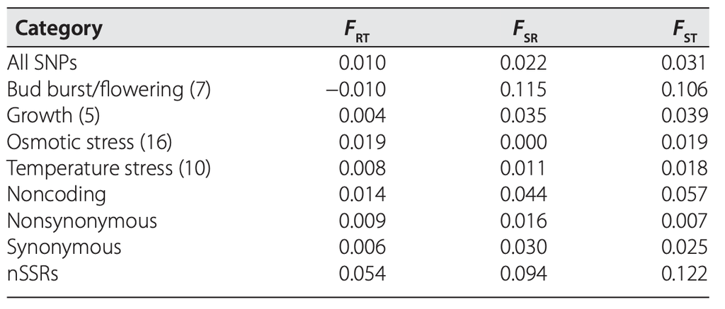

Landscape genomic analysis of candidate genes for climate adaptation in a California endemic oak, *Quercus lobata*

## Local adaptation can be driven be a few loci

Individual genes can be identified through selection scans or an redundancy analysis to connect loci with environemnt too (Sork et al. 2016)

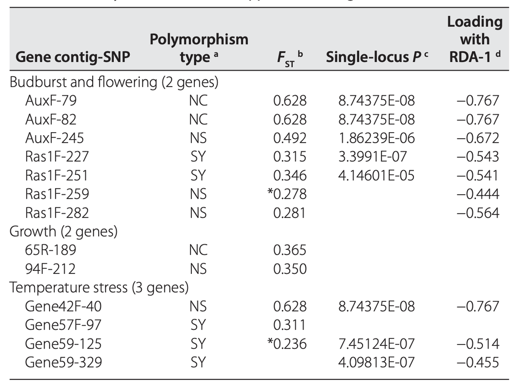

Individual candidate loci indicated in table

# Finding the loci

## Method I — $F_{ST}$ outlier scans

- Local adaptation **inflates $F_{ST}$** at the responsible loci above the genome-wide (demographic) background.
- Flag loci in the upper tail of the genome-wide $F_{ST}$ distribution.

Risk is that the $F_{ST}$ outliers may not reflect local adaptation but rather neutral processes like population structure or background selection. A null distribution under the coalescent is needed to help avoid false positives.

## Method I — $F_{ST}$ outlier scans

Convergent evolution in loss of photoperiod regulation in areas with reduced photoperiods in wheat. (Zhao et al. 2023)

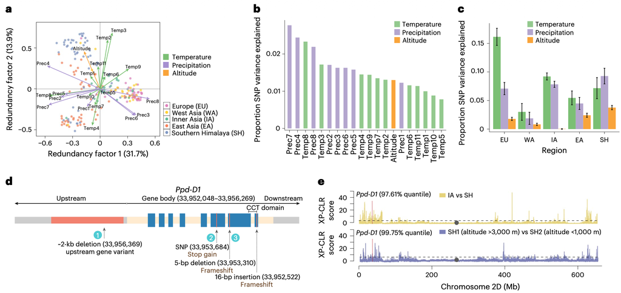

Manhattan plots map to loss of function in a candidate locus

# Redundancy analysis (RDA)

## Method II — genotype–environment association (GEA)

Regress allele frequency directly on an environmental variable $E$, **correcting for population structure**. The correction ensure fixed variation due to distance is not confused with environmental association
$$\mathrm{logit}\,p_\ell = \beta_0 + \beta_1 E + (\text{structure / random effect}) .$$

$p_\ell$ is the allele frequency at locus $\ell$ in a sampled population or individual, and $E$ is an environmental measurement at that same site. The **logit** is $\ln\!\big(p/(1-p)\big)$, which transforms the allele frequency to an unbound continuous distribution that can be used for regression.

$\beta_0$ is the intercept, and $\beta_1$ is the slope. The slope measures how much the locus’s frequency shifts per unit change in environment.

If $\beta_1 \neq 0$, then the locus is associated with environment more than expected due to chance alone.

## Univariate limitations

The regression before is **univariate**: one locus, one environemntal variable. But local adaptation is often **polygenic**: many allele frequencies changing a little together - **weak selection**.

Testing one locus at a time causes two big statistical problems: - **Multiple testing** — millions of SNPs × several climate variables. This will lead to a high false positive rate or a punishing multiple testing correction across thousands of loci. - It **misses covariation**. We often want to know which loci covary across clines or gradients.

## Multivariate solution: RDA

**RDA** analyzes everything at once. Two matrices:

- $\mathbf{Y}$: $n \times L$ — populations (or individuals) × loci (allele frequencies/genotypes).
- $\mathbf{X}$: $n \times p$ — the same sites × environmental predictors.

RDA is another ordination analysis, similar to our PCA. But, this is a **constrained ordination**. That means it is a PCA of the portion of genetic variation explained by the environmental predictors.

## Multivariate solution: RDA

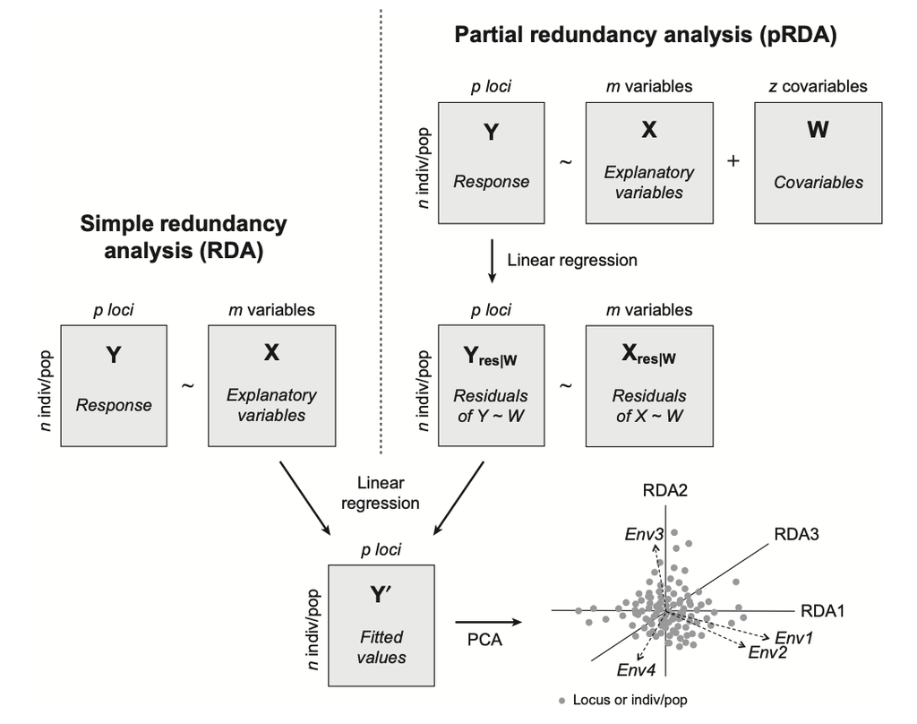

Schematic overview of multiple regression analysis with RDA

## Multivariate solution: RDA

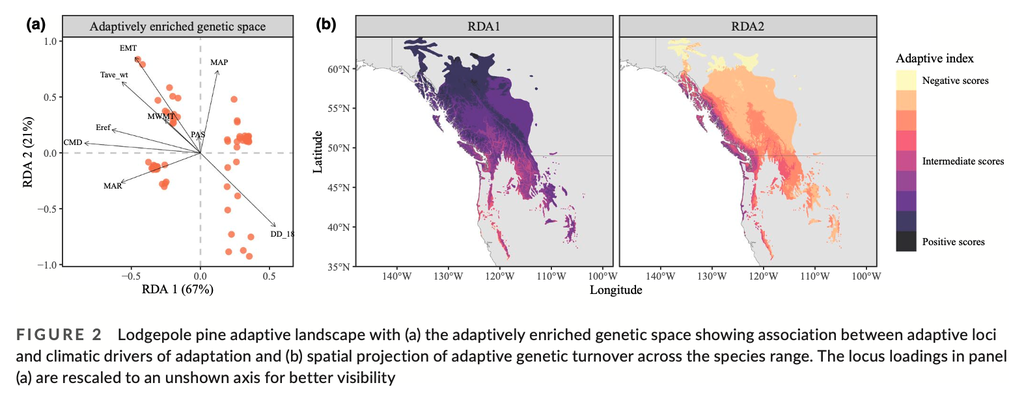

## Multivariate solution: RDA

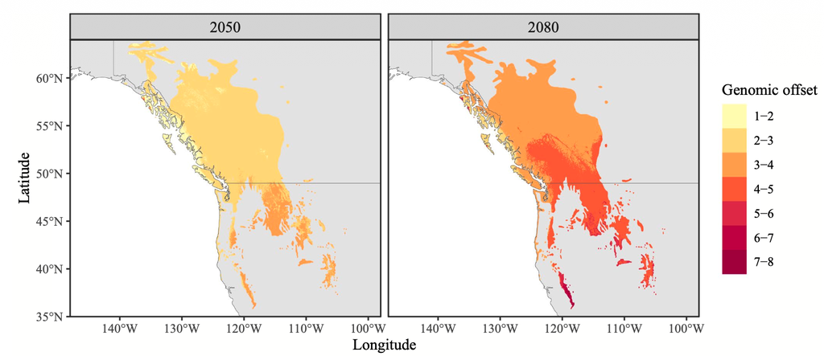

Potential for predicting future mismatch between today’s locally adapted genotypes and future environmental conditions from Capblancq and Forester (2021)

## $R^2$ and significance

**How much environment?** The total genetic variation in $\mathbf{Y}$ splits into the component explained by environment and a component not explained by environment. The environment fraction gives an $R^2$ like an ordinary linear regression. Report the **adjusted $R^2$** instead of the raw one, because raw $R^2$ always goes up when you add more predictors, even useless ones.

**Is it real?** A high $R^2$ can still show up by chance, so a **permutation test** helps differentiate a strong result from a weak one. Here, we randomly shuffle which environmental values go with which site and refit the model many times. The $R^2$ is recorded every permutation. If we do this enough, we get a null distribution to put a p-value on $R^2$.

## Pulling out candidate loci

Candidates are SNPs with **extreme loadings** on the significant RDA axes — the tails of the loading distribution (a common rule is $\pm 3$ SD) (Forester et al. 2018).

The axis a SNP loads on tells you **which environmental gradient** it is associated with.

This approach is part of a family of methods that are very powerful in genetics. Here are a few main flavors of the approach.

| Method | Flavor | Structure control | Best at |
| --- | --- | --- | --- |
| **RDA** | multivariate ordination | covariates via **pRDA** | **polygenic**, covarying signal |
| **LFMM** | univariate + latent factors | latent factors | single strong-effect loci |
| **BayPass** | Bayesian | allele-frequency covariance null | explicit demographic null |

# Key takeaways

## Summary - Review questions

- What would you expect if you performed reciprocal transplants of locally adapted populations along their primary environmental gradient?
- How do **$F_{ST}$ outliers** tests differ from genome scans with Tajima’s $D$ scans?
- How do you prevent an RDA from giving you false positives due to population structure?
- How would you design a population genomics project to detect local adaptation along a precipitation gradient? What would your strategy be for sampling populations and how many individuals per population?

# References

Antonovics, Janis, A. D. Bradshaw, and R. G. Turner. 1971. “Heavy Metal Tolerance in Plants.” *Advances in Ecological Research* 7: 1–85. https://doi.org/10.1016/S0065-2504(08)60202-0.

Capblancq, Thibaut, and Brenna R. Forester. 2021. “Redundancy Analysis: A Swiss Army Knife for Landscape Genomics.” *Methods in Ecology and Evolution* 12 (12): 2298–2309. https://doi.org/10.1111/2041-210X.13722.

Forester, Brenna R., Jesse R. Lasky, Helene H. Wagner, and Dean L. Urban. 2018. “Comparing Methods for Detecting Multilocus Adaptation with Multivariate Genotype–Environment Associations.” *Molecular Ecology* 27 (9): 2215–33. https://doi.org/10.1111/mec.14584.

Kawecki, Tadeusz J, and Dieter Ebert. 2004. “Conceptual Issues in Local Adaptation.” *Ecology Letters* 7 (12): 1225–41.

Lowry, David B, and John H Willis. 2010. “A Widespread Chromosomal Inversion Polymorphism Contributes to a Major Life-History Transition, Local Adaptation, and Reproductive Isolation.” *PLoS Biology* 8 (9): e1000500.

Papadopulos, Alexander ST, Andrew J Helmstetter, Owen G Osborne, Aaron A Comeault, Daniel P Wood, Edward A Straw, Laurence Mason, et al. 2021. “Rapid Parallel Adaptation to Anthropogenic Heavy Metal Pollution.” *Molecular Biology and Evolution* 38 (9): 3724–36.

Sork, Victoria L, Kevin Squire, Paul F Gugger, Stephanie E Steele, Eric D Levy, and Andrew J Eckert. 2016. “Landscape Genomic Analysis of Candidate Genes for Climate Adaptation in a California Endemic Oak, Quercus Lobata.” *American Journal of Botany* 103 (1): 33–46.

Zhao, Xuebo, Yafei Guo, Lipeng Kang, Changbin Yin, Aoyue Bi, Daxing Xu, Zhiliang Zhang, et al. 2023. “Population Genomics Unravels the Holocene History of Bread Wheat and Its Relatives.” *Nature Plants* 9 (3): 403–19.